# Homework 2 - DS2 - Neural Nets

# 2. Hot dog or not hot dog?

## a. Pre-process data so that it is acceptable by Keras (set folder structure, bring images to the same size, etc).

The folder structure with all of the images was downloaded to this [GitHub repository folder](https://github.com/cosmin-ticu/DS2-neural-nets/tree/main/data/hot-dog-not-hot-dog). The following code chunks that are commented out were used to create the validation set, as the data only provided training and test folder structures. The image sizes were also brought to the same size through the image generator function.

```r
# a, Pre-process data so that it is acceptable by Keras (set folder structure, bring images to the same size, etc).
# set parameters for data partitions
# set augmentation parameters just for the training set
train_datagen <- image_data_generator(rescale = 1/255)
validation_datagen <- image_data_generator(rescale = 1/255)
test_datagen <- image_data_generator(rescale = 1/255)

image_size <- c(150, 150)
batch_size <- 50

# validation_indeces_yes <- sample(list.files(paste0("F:/OneDrive - Central European University/Courses/Winter_Term/Data Science 2/assignment 2/DS2-neural-nets", "/data/hot-dog-not-hot-dog/train/hot_dog")), size = 150, replace = F)
# validation_indeces_no <- sample(list.files(paste0("F:/OneDrive - Central European University/Courses/Winter_Term/Data Science 2/assignment 2/DS2-neural-nets", "/data/hot-dog-not-hot-dog/train/not_hot_dog")), size = 150, replace = F)

# dir.create(paste0("F:/OneDrive - Central European University/Courses/Winter_Term/Data Science 2/assignment 2/DS2-neural-nets","/data/hot-dog-not-hot-dog/validation"))
# dir.create(paste0("F:/OneDrive - Central European University/Courses/Winter_Term/Data Science 2/assignment 2/DS2-neural-nets","/data/hot-dog-not-hot-dog/validation/hot_dog"))
# dir.create(paste0("F:/OneDrive - Central European University/Courses/Winter_Term/Data Science 2/assignment 2/DS2-neural-nets","/data/hot-dog-not-hot-dog/validation/not_hot_dog"))
#
# # move yes cases
# for (file in list.files(paste0("F:/OneDrive - Central European University/Courses/Winter_Term/Data Science 2/assignment 2/DS2-neural-nets", "/data/hot-dog-not-hot-dog/train/hot_dog"))) {
#   if (file %in% validation_indeces_yes){
#     file.move(paste0("F:/OneDrive - Central European University/Courses/Winter_Term/Data Science 2/assignment 2/DS2-neural-nets", "/data/hot-dog-not-hot-dog/train/hot_dog/", file), paste0("F:/OneDrive - Central European University/Courses/Winter_Term/Data Science 2/assignment 2/DS2-neural-nets","/data/hot-dog-not-hot-dog/validation/hot_dog/"))
#   }
# }
#
# # move no cases
# for (file in list.files(paste0("F:/OneDrive - Central European University/Courses/Winter_Term/Data Science 2/assignment 2/DS2-neural-nets", "/data/hot-dog-not-hot-dog/train/not_hot_dog"))) {
#   if (file %in% validation_indeces_no){
#     file.move(paste0("F:/OneDrive - Central European University/Courses/Winter_Term/Data Science 2/assignment 2/DS2-neural-nets", "/data/hot-dog-not-hot-dog/train/not_hot_dog/", file), paste0("F:/OneDrive - Central European University/Courses/Winter_Term/Data Science 2/assignment 2/DS2-neural-nets","/data/hot-dog-not-hot-dog/validation/not_hot_dog/"))
#   }
# }

train_generator <- flow_images_from_directory(
  file.path("F:/OneDrive - Central European University/Courses/Winter_Term/Data Science 2/assignment 2/DS2-neural-nets", "/data/hot-dog-not-hot-dog/train"), # Target directory
  train_datagen,              # Data generator
  target_size = image_size,  # Resizes all images to 150 × 150
  batch_size = batch_size,
  class_mode = "binary"       # binary_crossentropy loss for binary labels
)

validation_generator <- flow_images_from_directory(
  file.path("F:/OneDrive - Central European University/Courses/Winter_Term/Data Science 2/assignment 2/DS2-neural-nets", "/data/hot-dog-not-hot-dog/validation"),
  validation_datagen,
  target_size = image_size,
  batch_size = batch_size,
  class_mode = "binary"
)

test_generator <- flow_images_from_directory(
  file.path("F:/OneDrive - Central European University/Courses/Winter_Term/Data Science 2/assignment 2/DS2-neural-nets", "/data/hot-dog-not-hot-dog/test"), # Target directory
  test_datagen,
  target_size = image_size,
  batch_size = batch_size,
  class_mode = "binary"
)
```

## b. Estimate a convolutional neural network to predict if an image contains a hot dog or not. Evaluate your model on the test set.

A baseline CNN classification model was built. The following code shows the building process, summary statistics and the training history plot.

```r
# b, Estimate a convolutional neural network to predict if an image contains a hot dog or not. Evaluate your model on the test set.

### BASELINE MODEL --> Overfitted
# 3rd dimension refers to the color dimension
hot_dog_model_baseline <- keras_model_sequential()%>%
  layer_conv_2d(filters = 32,
                kernel_size = c(3, 3),
                activation = 'relu',
                input_shape = c(150, 150, 3)) %>%
  layer_max_pooling_2d(pool_size = c(2, 2)) %>%
  layer_conv_2d(filters = 64,
                kernel_size = c(3, 3),
                activation = 'relu') %>%
  layer_max_pooling_2d(pool_size = c(2, 2)) %>%
  layer_dropout(rate = 0.5) %>%
  layer_flatten() %>%
  layer_dense(units = 64, activation = 'relu') %>%
  layer_dropout(rate = 0.5) %>%
  layer_dense(units = 1, activation = "sigmoid")   # for binary

summary(hot_dog_model_baseline)
```

```
## Model: "sequential_11"
## ________________________________________________________________________________
## Layer (type)                        Output Shape                    Param #
## ================================================================================
## conv2d_9 (Conv2D)                   (None, 148, 148, 32)            896
## ________________________________________________________________________________
## max_pooling2d_8 (MaxPooling2D)      (None, 74, 74, 32)              0
## ________________________________________________________________________________
## conv2d_8 (Conv2D)                   (None, 72, 72, 64)              18496
## ________________________________________________________________________________
## max_pooling2d_7 (MaxPooling2D)      (None, 36, 36, 64)              0
## ________________________________________________________________________________
## dropout_10 (Dropout)                (None, 36, 36, 64)              0
## ________________________________________________________________________________
## flatten_5 (Flatten)                 (None, 82944)                   0
## ________________________________________________________________________________
## dense_27 (Dense)                    (None, 64)                      5308480
## ________________________________________________________________________________
## dropout_9 (Dropout)                 (None, 64)                      0
## ________________________________________________________________________________
## dense_26 (Dense)                    (None, 1)                       65
## ================================================================================
## Total params: 5,327,937
## Trainable params: 5,327,937
## Non-trainable params: 0
## ________________________________________________________________________________
```

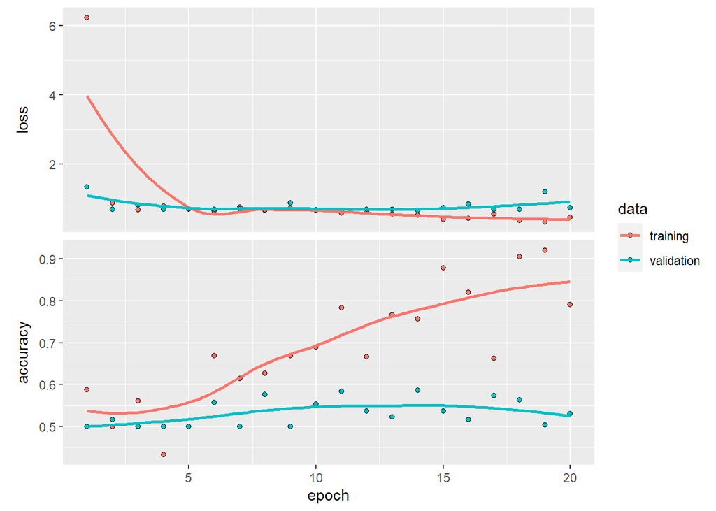

```r
hot_dog_model_baseline %>% compile(
  loss = "binary_crossentropy",
  optimizer = 'rmsprop',
  metrics = c("accuracy")
)

# set.seed(1234)
# hot_dog_baseline_RDS <- hot_dog_model_baseline %>% fit(
#   train_generator,
#   steps_per_epoch = 198 / batch_size, # divide size of training dataset by batch size
#   epochs = 20,
#   validation_data = validation_generator,
#   validation_steps = 300 / batch_size # divide size of training dataset by batch size
# )
#
# saveRDS(hot_dog_baseline_RDS, file = "data/hot_dog_baseline_RDS.rds")
hot_dog_baseline_RDS <- readRDS(file = "F:/OneDrive - Central European University/Courses/Winter_Term/Data Science 2/assignment 2/DS2-neural-nets/data/hot_dog_baseline_RDS.rds")

# Save the model
# save_model_hdf5(hot_dog_model_baseline, "data/hot_dog_model_baseline.h5")

# Recreate the exact same model purely from the file
hot_dog_model_baseline <- load_model_hdf5("F:/OneDrive - Central European University/Courses/Winter_Term/Data Science 2/assignment 2/DS2-neural-nets/data/hot_dog_model_baseline.h5")

# evaluate model
hot_dog_model_baseline_eval <- as.data.frame(evaluate(hot_dog_model_baseline, test_generator))
# LIKELY TO BE THE WORST MODEL IN THE HISTORY OF THIS CLASS

plot(hot_dog_baseline_RDS) # --> terrible
```

```r
knitr::kable(hot_dog_model_baseline_eval, caption = 'Test set performance of baseline CNN image classifier') %>%
  kable_styling( position = "center", latex_options = 'hold_position', bootstrap_options = c("striped", "hover"))
```

Test set performance of baseline CNN image classifier

|  | evaluate(hot_dog_model_baseline, test_generator) |
| --- | --- |
| loss | 0.7482598 |
| accuracy | 0.5180000 |

Due to the bad performance of the first CNN classifier, a more complex model was built in order to increase accuracy. If accuracy does not increase, at least the overfitting trends of the baseline model are expected to be overcome. We inspect the building process, summary statistics and plots below.

```r
### FINAL MODEL
hot_dog_model_final <- keras_model_sequential()%>%
  layer_conv_2d(filters = 32,
                kernel_size = c(3, 3),
                activation = 'relu',
                input_shape = c(150, 150, 3)) %>%
  layer_max_pooling_2d(pool_size = c(2, 2)) %>%
  layer_conv_2d(filters = 32,
                kernel_size = c(3, 3),
                activation = 'relu') %>%
  layer_max_pooling_2d(pool_size = c(2, 2)) %>%
  layer_conv_2d(filters = 64,
                kernel_size = c(3, 3),
                activation = 'relu') %>%
  layer_max_pooling_2d(pool_size = c(2, 2)) %>%
  layer_conv_2d(filters = 16,
                kernel_size = c(3, 3),
                activation = 'relu') %>%
  layer_max_pooling_2d(pool_size = c(2, 2)) %>%
  layer_dropout(rate = 0.5) %>%
  layer_flatten() %>%
  layer_dense(units = 64, activation = 'relu') %>%
  layer_dropout(rate = 0.5) %>%
  layer_dense(units = 1, activation = "sigmoid")   # for binary

summary(hot_dog_model_final)
```

```
## Model: "sequential_12"
## ________________________________________________________________________________
## Layer (type)                        Output Shape                    Param #
## ================================================================================
## conv2d_13 (Conv2D)                  (None, 148, 148, 32)            896
## ________________________________________________________________________________
## max_pooling2d_12 (MaxPooling2D)     (None, 74, 74, 32)              0
## ________________________________________________________________________________
## conv2d_12 (Conv2D)                  (None, 72, 72, 32)              9248
## ________________________________________________________________________________
## max_pooling2d_11 (MaxPooling2D)     (None, 36, 36, 32)              0
## ________________________________________________________________________________
## conv2d_11 (Conv2D)                  (None, 34, 34, 64)              18496
## ________________________________________________________________________________
## max_pooling2d_10 (MaxPooling2D)     (None, 17, 17, 64)              0
## ________________________________________________________________________________
## conv2d_10 (Conv2D)                  (None, 15, 15, 16)              9232
## ________________________________________________________________________________
## max_pooling2d_9 (MaxPooling2D)      (None, 7, 7, 16)                0
## ________________________________________________________________________________
## dropout_12 (Dropout)                (None, 7, 7, 16)                0
## ________________________________________________________________________________
## flatten_6 (Flatten)                 (None, 784)                     0
## ________________________________________________________________________________
## dense_29 (Dense)                    (None, 64)                      50240
## ________________________________________________________________________________
## dropout_11 (Dropout)                (None, 64)                      0
## ________________________________________________________________________________
## dense_28 (Dense)                    (None, 1)                       65
## ================================================================================
## Total params: 88,177
## Trainable params: 88,177
## Non-trainable params: 0
## ________________________________________________________________________________
```

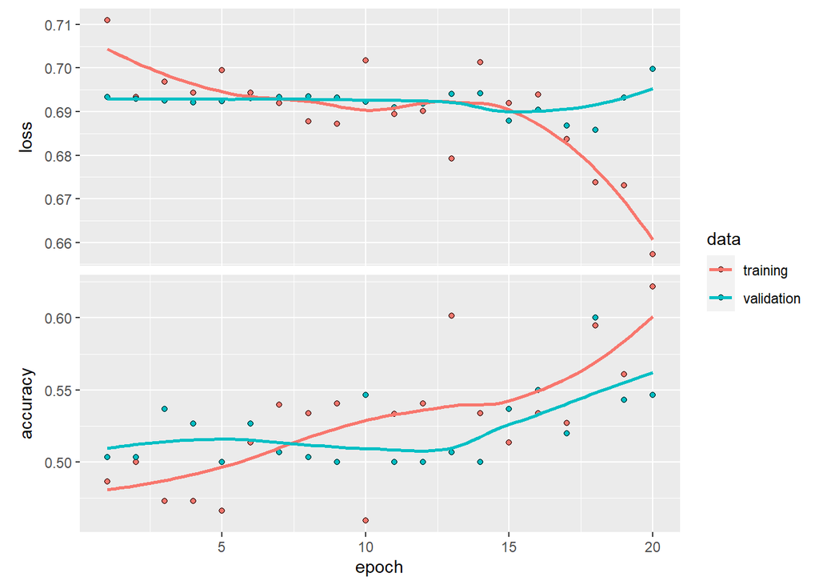

```r
hot_dog_model_final %>% compile(
  loss = "binary_crossentropy",
  optimizer = 'rmsprop',
  metrics = c("accuracy")
)

# set.seed(1234)
# hot_dog_final_RDS <- hot_dog_model_final %>% fit(
#   train_generator,
#   steps_per_epoch = 198 / batch_size, # divide size of training dataset by batch size
#   epochs = 20,
#   validation_data = validation_generator,
#   validation_steps = 300 / batch_size, # divide size of training dataset by batch size
#   callback_reduce_lr_on_plateau(monitor = "val_loss", factor = 0.1) # if crossentropy loss plateaus, change LR
# )
#
# saveRDS(hot_dog_final_RDS, file = "data/hot_dog_final_RDS.rds")
hot_dog_final_RDS <- readRDS(file = "F:/OneDrive - Central European University/Courses/Winter_Term/Data Science 2/assignment 2/DS2-neural-nets/data/hot_dog_final_RDS.rds")

# Save the model
# save_model_hdf5(hot_dog_model_final, "data/hot_dog_model_final.h5")

# Recreate the exact same model purely from the file
hot_dog_model_final <- load_model_hdf5("F:/OneDrive - Central European University/Courses/Winter_Term/Data Science 2/assignment 2/DS2-neural-nets/data/hot_dog_model_final.h5")

# evaluate model
hot_dog_final_model_eval <- as.data.frame(evaluate(hot_dog_model_final, test_generator))
# better than a coin-flip yo

plot(hot_dog_final_RDS) # better
```

```r
knitr::kable(hot_dog_final_model_eval, caption = 'Test set performance of chosen CNN image classifier') %>%
  kable_styling( position = "center", latex_options = 'hold_position', bootstrap_options = c("striped", "hover"))
```

Test set performance of chosen CNN image classifier

|  | evaluate(hot_dog_model_final, test_generator) |
| --- | --- |
| loss | 0.7223248 |
| accuracy | 0.4900000 |

```r
# initialize empty model eval list
model_eval_list <- list()
model_eval_list['final_model_no_augmentation'] <- as.data.frame(evaluate(hot_dog_model_final, validation_generator))
```

## c. Could data augmentation techniques help with achieving higher predictive accuracy? Try some augmentations that you think make sense and compare

A few augmentation techniques were used. The notable ones are presented here in the model building process. In order to add data augmentation, the image generator parameters were tweaked, oftentimes translating into more zoomed in pictures, rotated pics and brighter images. The first data augmentation attempt can be seen below.

```r
# c, Could data augmentation techniques help with achieving higher predictive accuracy?

### FIRST DATA AUGMENTATION
# reinitialize training generator for data augmentation
train_datagen = image_data_generator(
  rescale = 1/255,
  rotation_range = 40,
  width_shift_range = 0.2,
  height_shift_range = 0.2,
  shear_range = 0.2,
  zoom_range = 0.2, # crops corners of most photos --> useful!
  horizontal_flip = TRUE,
  fill_mode = "nearest"
)
train_generator <- flow_images_from_directory(
  file.path("F:/OneDrive - Central European University/Courses/Winter_Term/Data Science 2/assignment 2/DS2-neural-nets", "/data/hot-dog-not-hot-dog/train"), # Target directory
  train_datagen,              # Data generator
  target_size = image_size,  # Resizes all images to 150 × 150
  batch_size = batch_size,
  class_mode = "binary"       # binary_crossentropy loss for binary labels
)
# set.seed(1234)
# hot_dog_final_aug1_RDS <- hot_dog_model_final %>% fit(
#   train_generator,
#   steps_per_epoch = 198 / batch_size, # divide size of training dataset by batch size
#   epochs = 20,
#   validation_data = validation_generator,
#   validation_steps = 300 / batch_size, # divide size of training dataset by batch size
#   callback_reduce_lr_on_plateau(monitor = "val_loss", factor = 0.1) # if crossentropy loss plateaus, change LR
# )
#
# # Save the model
# save_model_hdf5(hot_dog_model_final, "data/hot_dog_model_aug1.h5")

# Recreate the exact same model purely from the file
hot_dog_model_final <- load_model_hdf5("F:/OneDrive - Central European University/Courses/Winter_Term/Data Science 2/assignment 2/DS2-neural-nets/data/hot_dog_model_aug1.h5")

# saveRDS(hot_dog_final_aug1_RDS, file = "data/hot_dog_final_aug1_RDS.rds")
hot_dog_final_aug1_RDS <- readRDS(file = "F:/OneDrive - Central European University/Courses/Winter_Term/Data Science 2/assignment 2/DS2-neural-nets/data/hot_dog_final_aug1_RDS.rds")

model_eval_list['first_try_augmentation'] <- as.data.frame(evaluate(hot_dog_model_final, validation_generator))
```

The second data augmentation is more aggressive than the first one, with a higher zoom, rotation and brightness range. It is expected that this model will perform better.

```r
### SECOND DATA AUGMENTATION
# reinitialize training generator for data augmentation
train_datagen = image_data_generator(
  rescale = 1/255,
  rotation_range = 90,
  width_shift_range = 0.4,
  height_shift_range = 0.4,
  zoom_range = 0.5, # crops corners of most photos --> useful!
  brightness_range = c(1,1.5),
  fill_mode = "nearest" # applies to new sections of image after rotations etc.
)
train_generator <- flow_images_from_directory(
  file.path("F:/OneDrive - Central European University/Courses/Winter_Term/Data Science 2/assignment 2/DS2-neural-nets", "/data/hot-dog-not-hot-dog/train"), # Target directory
  train_datagen,              # Data generator
  target_size = image_size,  # Resizes all images to 150 × 150
  batch_size = batch_size,
  class_mode = "binary"       # binary_crossentropy loss for binary labels
)
# set.seed(1234)
# hot_dog_final_aug2_RDS <- hot_dog_model_final %>% fit(
#   train_generator,
#   steps_per_epoch = 198 / batch_size, # divide size of training dataset by batch size
#   epochs = 20,
#   validation_data = validation_generator,
#   validation_steps = 300 / batch_size, # divide size of training dataset by batch size
#   callback_reduce_lr_on_plateau(monitor = "val_loss", factor = 0.1) # if crossentropy loss plateaus, change LR
# )
#
# # Save the model
# save_model_hdf5(hot_dog_model_final, "data/hot_dog_model_aug2.h5")

# Recreate the exact same model purely from the file
hot_dog_model_final <- load_model_hdf5("F:/OneDrive - Central European University/Courses/Winter_Term/Data Science 2/assignment 2/DS2-neural-nets/data/hot_dog_model_aug2.h5")

# saveRDS(hot_dog_final_aug2_RDS, file = "data/hot_dog_final_aug2_RDS.rds")
hot_dog_final_aug2_RDS <- readRDS(file = "F:/OneDrive - Central European University/Courses/Winter_Term/Data Science 2/assignment 2/DS2-neural-nets/data/hot_dog_final_aug2_RDS.rds")

model_eval_list['second_try_augmentation'] <- as.data.frame(evaluate(hot_dog_model_final, validation_generator))
# accuracy is significantly higher --> proof that augmentation on training set works?!
```

The third attempt at data augmentation uses a lower zoom range, lower rotation, but higher 1-dimensional shifts as well as a different fill mode. The fill mode applied to new sections of images after rotations, zooms, crops in order to fill the “missing pixels”. The standard in data augmentation is the nearest approach. For the third model, the wrap mode is applied for comparison’s sake to the first 2 models that use standard fill mode techniques.

```r
### THIRD DATA AUGMENTATION
# reinitialize training generator for data augmentation
train_datagen = image_data_generator(
  rescale = 1/255,
  rotation_range = 10,
  width_shift_range = 0.5,
  height_shift_range = 0.5,
  zoom_range = 0.1, # crops corners of most photos --> useful!
  brightness_range = c(1.5,2),
  fill_mode = "wrap" # applies to new sections of image after rotations etc.
)
train_generator <- flow_images_from_directory(
  file.path("F:/OneDrive - Central European University/Courses/Winter_Term/Data Science 2/assignment 2/DS2-neural-nets", "/data/hot-dog-not-hot-dog/train"), # Target directory
  train_datagen,              # Data generator
  target_size = image_size,  # Resizes all images to 150 × 150
  batch_size = batch_size,
  class_mode = "binary"       # binary_crossentropy loss for binary labels
)
# set.seed(1234)
# hot_dog_final_aug3_RDS <- hot_dog_model_final %>% fit(
#   train_generator,
#   steps_per_epoch = 198 / batch_size, # divide size of training dataset by batch size
#   epochs = 20,
#   validation_data = validation_generator,
#   validation_steps = 300 / batch_size, # divide size of training dataset by batch size
#   callback_reduce_lr_on_plateau(monitor = "val_loss", factor = 0.1) # if crossentropy loss plateaus, change LR
# )

# Save the model
# save_model_hdf5(hot_dog_model_final, "data/hot_dog_model_aug3.h5")

# Recreate the exact same model purely from the file
hot_dog_model_final <- load_model_hdf5("F:/OneDrive - Central European University/Courses/Winter_Term/Data Science 2/assignment 2/DS2-neural-nets/data/hot_dog_model_aug3.h5")

# saveRDS(hot_dog_final_aug3_RDS, file = "data/hot_dog_final_aug3_RDS.rds")
hot_dog_final_aug3_RDS <- readRDS(file = "F:/OneDrive - Central European University/Courses/Winter_Term/Data Science 2/assignment 2/DS2-neural-nets/data/hot_dog_final_aug3_RDS.rds")

model_eval_list['third_try_augmentation'] <- as.data.frame(evaluate(hot_dog_model_final, validation_generator))
# model performance seems to stay relatively constant between training and validation
```

Observing a comparison table between the final CNN model with no augmentation and its augmented counterparts on the validation set:

```r
model_eval_hot_dog <- as.data.frame(model_eval_list)
row.names(model_eval_hot_dog) <- c('loss','accuracy')
knitr::kable(model_eval_hot_dog, caption = "", digits = 3 ) %>%
  kable_styling( position = "center", latex_options = 'hold_position', bootstrap_options = c("striped", "hover"))
```

|  | final_model_no_augmentation | first_try_augmentation | second_try_augmentation | third_try_augmentation |
| --- | --- | --- | --- | --- |
| loss | 0.700 | 0.685 | 0.684 | 0.685 |
| accuracy | 0.547 | 0.537 | 0.620 | 0.540 |

```r
## Conclusion to this point - augmentation does help performance
```

## d. Try to rely on some pre-built neural networks to aid prediction. Can you achieve a better performance using transfer learning for this problem?

While data augmentation did help the predictive power of the models, neural networks are so popular these days that algorithms are open-sourced and through the keras package, we can have access to notable image classification NN/CNN algos.

```r
# reinitialize training generator for data augmentation with best augmentation parameters
train_datagen = image_data_generator(
  rescale = 1/255,
  rotation_range = 40,
  width_shift_range = 0.2,
  height_shift_range = 0.2,
  shear_range = 0.2,
  zoom_range = 0.2, # crops corners of most photos --> useful!
  horizontal_flip = TRUE,
  fill_mode = "nearest"
)
train_generator <- flow_images_from_directory(
  file.path("F:/OneDrive - Central European University/Courses/Winter_Term/Data Science 2/assignment 2/DS2-neural-nets", "/data/hot-dog-not-hot-dog/train"), # Target directory
  train_datagen,              # Data generator
  target_size = image_size,  # Resizes all images to 150 × 150
  batch_size = batch_size,
  class_mode = "binary"       # binary_crossentropy loss for binary labels
)
```

For the first transfer learning algorithm, the famous Google Neural Network model is chosen, called Inception V3. Its layers will be added to a model containing a pooling layer, a dense layer and a final output layer for the binary classification. The data fed into this algorithm will contain the augmented training set.

```r
# d, Try to rely on some pre-built neural networks to aid prediction.
# Can you achieve a better performance using transfer learning for this problem?

##### FIRST TRY
# we will improve the augmented final model
# create the base pre-trained model
conv_base <- application_inception_v3(
  weights = "imagenet",
  include_top = FALSE,
  input_shape = c(image_size, 3)
)

summary(conv_base)
```

```
## Model: "inception_v3"
## ________________________________________________________________________________
## Layer (type)              Output Shape      Param #  Connected to
## ================================================================================
## input_1 (InputLayer)      [(None, 150, 150, 0
## ________________________________________________________________________________
## conv2d_14 (Conv2D)        (None, 74, 74, 32 864      input_1[0][0]
## ________________________________________________________________________________
## batch_normalization (Batc (None, 74, 74, 32 96       conv2d_14[0][0]
## ________________________________________________________________________________
## activation (Activation)   (None, 74, 74, 32 0        batch_normalization[0][0]
## ________________________________________________________________________________
## conv2d_15 (Conv2D)        (None, 72, 72, 32 9216     activation[0][0]
## ________________________________________________________________________________
## batch_normalization_1 (Ba (None, 72, 72, 32 96       conv2d_15[0][0]
## ________________________________________________________________________________
## activation_1 (Activation) (None, 72, 72, 32 0        batch_normalization_1[0][0]
## ________________________________________________________________________________
## conv2d_16 (Conv2D)        (None, 72, 72, 64 18432    activation_1[0][0]
## ________________________________________________________________________________
## batch_normalization_2 (Ba (None, 72, 72, 64 192      conv2d_16[0][0]
## ________________________________________________________________________________
## activation_2 (Activation) (None, 72, 72, 64 0        batch_normalization_2[0][0]
## ________________________________________________________________________________
## max_pooling2d_13 (MaxPool (None, 35, 35, 64 0        activation_2[0][0]
## ________________________________________________________________________________
## conv2d_17 (Conv2D)        (None, 35, 35, 80 5120     max_pooling2d_13[0][0]
## ________________________________________________________________________________
## batch_normalization_3 (Ba (None, 35, 35, 80 240      conv2d_17[0][0]
## ________________________________________________________________________________
## activation_3 (Activation) (None, 35, 35, 80 0        batch_normalization_3[0][0]
## ________________________________________________________________________________
## conv2d_18 (Conv2D)        (None, 33, 33, 19 138240   activation_3[0][0]
## ________________________________________________________________________________
## batch_normalization_4 (Ba (None, 33, 33, 19 576      conv2d_18[0][0]
## ________________________________________________________________________________
## activation_4 (Activation) (None, 33, 33, 19 0        batch_normalization_4[0][0]
## ________________________________________________________________________________
## max_pooling2d_14 (MaxPool (None, 16, 16, 19 0        activation_4[0][0]
## ________________________________________________________________________________
```

[output cut: 610 more lines]

```
## ________________________________________________________________________________
## concatenate_1 (Concatenat (None, 3, 3, 768) 0        activation_91[0][0]
##                                                      activation_92[0][0]
## ________________________________________________________________________________
## activation_93 (Activation (None, 3, 3, 192) 0        batch_normalization_93[0][0
## ________________________________________________________________________________
## mixed10 (Concatenate)     (None, 3, 3, 2048 0        activation_85[0][0]
##                                                      mixed9_1[0][0]
##                                                      concatenate_1[0][0]
##                                                      activation_93[0][0]
## ================================================================================
## Total params: 21,802,784
## Trainable params: 21,768,352
## Non-trainable params: 34,432
## ________________________________________________________________________________
```

```r
# The convolutional base of inception has 21,768,352 parameters, which is very large

# freeze all convolutional inception V3 layers
freeze_weights(conv_base)

### FINAL MODEL + Transfer Learning w/ Inception V3
hot_dog_model_final_inceptionV3 <- keras_model_sequential()%>%
  conv_base %>%
  layer_global_average_pooling_2d() %>%
  layer_dense(units = 16, activation = 'relu') %>%
  layer_dense(units = 1, activation = 'sigmoid')

hot_dog_model_final_inceptionV3 %>% compile(
  loss = "binary_crossentropy",
  optimizer = 'rmsprop',
  metrics = c("accuracy")
)

# reinitialize training generator for data augmentation with best augmentation parameters
train_datagen = image_data_generator(
  rescale = 1/255,
  rotation_range = 40,
  width_shift_range = 0.2,
  height_shift_range = 0.2,
  shear_range = 0.2,
  zoom_range = 0.2, # crops corners of most photos --> useful!
  horizontal_flip = TRUE,
  fill_mode = "nearest"
)
train_generator <- flow_images_from_directory(
  file.path("F:/OneDrive - Central European University/Courses/Winter_Term/Data Science 2/assignment 2/DS2-neural-nets", "/data/hot-dog-not-hot-dog/train"), # Target directory
  train_datagen,              # Data generator
  target_size = image_size,  # Resizes all images to 150 × 150
  batch_size = batch_size,
  class_mode = "binary"       # binary_crossentropy loss for binary labels
)
# set.seed(1234)
# hot_dog_model_final_inceptionV3_RDS <- hot_dog_model_final_inceptionV3 %>% fit(
#   train_generator,
#   steps_per_epoch = 198 / batch_size, # divide size of training dataset by batch size
#   epochs = 10,
#   validation_data = validation_generator,
#   validation_steps = 300 / batch_size, # divide size of training dataset by batch size
#   callback_reduce_lr_on_plateau(monitor = "val_loss", factor = 0.1) # if crossentropy loss plateaus, change LR
# )

# Save the model
# save_model_hdf5(hot_dog_model_final_inceptionV3, "data/hot_dog_model_final_inceptionV3.h5")

# Recreate the exact same model purely from the file
hot_dog_model_final_inceptionV3 <- load_model_hdf5("F:/OneDrive - Central European University/Courses/Winter_Term/Data Science 2/assignment 2/DS2-neural-nets/data/hot_dog_model_final_inceptionV3.h5")

# saveRDS(hot_dog_model_final_inceptionV3_RDS, file = "data/hot_dog_model_final_inceptionV3_RDS.rds")
hot_dog_model_final_inceptionV3_RDS <- readRDS(file = "F:/OneDrive - Central European University/Courses/Winter_Term/Data Science 2/assignment 2/DS2-neural-nets/data/hot_dog_model_final_inceptionV3_RDS.rds")

model_eval_list['final_conv_inceptionV3_augmented'] <-
  as.data.frame(evaluate(hot_dog_model_final_inceptionV3, validation_generator))
```

For the second transfer learning algorithm, the Mobilenet Network model is chosen. Its layers will be added to a model containing a pooling layer, a dense layer and a final output layer for the binary classification. The data fed into this algorithm will contain the augmented training set.

```r
##### SECOND TRY
# we will improve the augmented final model
# create the base pre-trained model
base_model <- application_mobilenet(
  weights = 'imagenet',
  include_top = FALSE,
  input_shape = c(image_size, 3))

summary(base_model)
```

```
## Model: "mobilenet_1.00_224"
## ________________________________________________________________________________
## Layer (type)                        Output Shape                    Param #
## ================================================================================
## input_2 (InputLayer)                [(None, 150, 150, 3)]           0
## ________________________________________________________________________________
## conv1 (Conv2D)                      (None, 75, 75, 32)              864
## ________________________________________________________________________________
## conv1_bn (BatchNormalization)       (None, 75, 75, 32)              128
## ________________________________________________________________________________
## conv1_relu (ReLU)                   (None, 75, 75, 32)              0
## ________________________________________________________________________________
## conv_dw_1 (DepthwiseConv2D)         (None, 75, 75, 32)              288
## ________________________________________________________________________________
## conv_dw_1_bn (BatchNormalization)   (None, 75, 75, 32)              128
## ________________________________________________________________________________
## conv_dw_1_relu (ReLU)               (None, 75, 75, 32)              0
## ________________________________________________________________________________
## conv_pw_1 (Conv2D)                  (None, 75, 75, 64)              2048
## ________________________________________________________________________________
## conv_pw_1_bn (BatchNormalization)   (None, 75, 75, 64)              256
## ________________________________________________________________________________
## conv_pw_1_relu (ReLU)               (None, 75, 75, 64)              0
## ________________________________________________________________________________
## conv_pad_2 (ZeroPadding2D)          (None, 76, 76, 64)              0
## ________________________________________________________________________________
## conv_dw_2 (DepthwiseConv2D)         (None, 37, 37, 64)              576
## ________________________________________________________________________________
## conv_dw_2_bn (BatchNormalization)   (None, 37, 37, 64)              256
## ________________________________________________________________________________
## conv_dw_2_relu (ReLU)               (None, 37, 37, 64)              0
## ________________________________________________________________________________
## conv_pw_2 (Conv2D)                  (None, 37, 37, 128)             8192
## ________________________________________________________________________________
## conv_pw_2_bn (BatchNormalization)   (None, 37, 37, 128)             512
## ________________________________________________________________________________
## conv_pw_2_relu (ReLU)               (None, 37, 37, 128)             0
## ________________________________________________________________________________
## conv_dw_3 (DepthwiseConv2D)         (None, 37, 37, 128)             1152
## ________________________________________________________________________________
```

[output cut: 125 more lines]

```
## ________________________________________________________________________________
## conv_dw_13_bn (BatchNormalization)  (None, 4, 4, 1024)              4096
## ________________________________________________________________________________
## conv_dw_13_relu (ReLU)              (None, 4, 4, 1024)              0
## ________________________________________________________________________________
## conv_pw_13 (Conv2D)                 (None, 4, 4, 1024)              1048576
## ________________________________________________________________________________
## conv_pw_13_bn (BatchNormalization)  (None, 4, 4, 1024)              4096
## ________________________________________________________________________________
## conv_pw_13_relu (ReLU)              (None, 4, 4, 1024)              0
## ================================================================================
## Total params: 3,228,864
## Trainable params: 3,206,976
## Non-trainable params: 21,888
## ________________________________________________________________________________
```

```r
# The convolutional base of mobilenet has 3,228,864 parameters, which is also very large

# freeze all convolutional mobilenet layers
freeze_weights(base_model)

### FINAL MODEL + Transfer Learning w/ Mobilenet
hot_dog_model_final_mobilenet <- keras_model_sequential()%>%
  base_model %>%
  layer_global_average_pooling_2d() %>%
  layer_dense(units = 16, activation = 'relu') %>%
  layer_dense(units = 1, activation = 'sigmoid')

hot_dog_model_final_mobilenet %>% compile(
  loss = "binary_crossentropy",
  optimizer = 'rmsprop',
  metrics = c("accuracy")
)

# set.seed(1234)
# hot_dog_model_final_mobilenet_RDS <- hot_dog_model_final_mobilenet %>% fit(
#   train_generator,
#   steps_per_epoch = 198 / batch_size, # divide size of training dataset by batch size
#   epochs = 10,
#   validation_data = validation_generator,
#   validation_steps = 300 / batch_size, # divide size of training dataset by batch size
#   callback_reduce_lr_on_plateau(monitor = "val_loss", factor = 0.1) # if crossentropy loss plateaus, change LR
# )

# Save the model
# save_model_hdf5(hot_dog_model_final_mobilenet, "data/hot_dog_model_final_mobilenet.h5")

# Recreate the exact same model purely from the file
hot_dog_model_final_mobilenet <- load_model_hdf5("F:/OneDrive - Central European University/Courses/Winter_Term/Data Science 2/assignment 2/DS2-neural-nets/data/hot_dog_model_final_mobilenet.h5")

# saveRDS(hot_dog_model_final_mobilenet_RDS, file = "data/hot_dog_model_final_mobilenet_RDS.rds")
hot_dog_model_final_mobilenet_RDS <- readRDS(file = "F:/OneDrive - Central European University/Courses/Winter_Term/Data Science 2/assignment 2/DS2-neural-nets/data/hot_dog_model_final_mobilenet_RDS.rds")

model_eval_list['final_conv_mobilenet_augmented'] <-
  as.data.frame(evaluate(hot_dog_model_final_mobilenet, validation_generator))
```

For the third transfer learning algorithm, the Resnet (Residual Net) Network model is chosen. Its layers will be added to a model containing a pooling layer, a dense layer and a final output layer for the binary classification. The data fed into this algorithm will contain the augmented training set.

```r
##### THIRD TRY
# we will improve the augmented final model
# create the base pre-trained model
resnet50_model <- application_resnet50(
  input_shape = c(image_size, 3),
  weights = 'imagenet',
  include_top = FALSE
)

summary(resnet50_model)
```

```
## Model: "resnet50"
## ________________________________________________________________________________
## Layer (type)              Output Shape      Param #  Connected to
## ================================================================================
## input_3 (InputLayer)      [(None, 150, 150, 0
## ________________________________________________________________________________
## conv1_pad (ZeroPadding2D) (None, 156, 156,  0        input_3[0][0]
## ________________________________________________________________________________
## conv1_conv (Conv2D)       (None, 75, 75, 64 9472     conv1_pad[0][0]
## ________________________________________________________________________________
## conv1_bn (BatchNormalizat (None, 75, 75, 64 256      conv1_conv[0][0]
## ________________________________________________________________________________
## conv1_relu (Activation)   (None, 75, 75, 64 0        conv1_bn[0][0]
## ________________________________________________________________________________
## pool1_pad (ZeroPadding2D) (None, 77, 77, 64 0        conv1_relu[0][0]
## ________________________________________________________________________________
## pool1_pool (MaxPooling2D) (None, 38, 38, 64 0        pool1_pad[0][0]
## ________________________________________________________________________________
## conv2_block1_1_conv (Conv (None, 38, 38, 64 4160     pool1_pool[0][0]
## ________________________________________________________________________________
## conv2_block1_1_bn (BatchN (None, 38, 38, 64 256      conv2_block1_1_conv[0][0]
## ________________________________________________________________________________
## conv2_block1_1_relu (Acti (None, 38, 38, 64 0        conv2_block1_1_bn[0][0]
## ________________________________________________________________________________
## conv2_block1_2_conv (Conv (None, 38, 38, 64 36928    conv2_block1_1_relu[0][0]
## ________________________________________________________________________________
## conv2_block1_2_bn (BatchN (None, 38, 38, 64 256      conv2_block1_2_conv[0][0]
## ________________________________________________________________________________
## conv2_block1_2_relu (Acti (None, 38, 38, 64 0        conv2_block1_2_bn[0][0]
## ________________________________________________________________________________
## conv2_block1_0_conv (Conv (None, 38, 38, 25 16640    pool1_pool[0][0]
## ________________________________________________________________________________
## conv2_block1_3_conv (Conv (None, 38, 38, 25 16640    conv2_block1_2_relu[0][0]
## ________________________________________________________________________________
## conv2_block1_0_bn (BatchN (None, 38, 38, 25 1024     conv2_block1_0_conv[0][0]
## ________________________________________________________________________________
## conv2_block1_3_bn (BatchN (None, 38, 38, 25 1024     conv2_block1_3_conv[0][0]
## ________________________________________________________________________________
## conv2_block1_add (Add)    (None, 38, 38, 25 0        conv2_block1_0_bn[0][0]
##                                                      conv2_block1_3_bn[0][0]
```

[output cut: 319 more lines]

```
## conv5_block3_2_relu (Acti (None, 5, 5, 512) 0        conv5_block3_2_bn[0][0]
## ________________________________________________________________________________
## conv5_block3_3_conv (Conv (None, 5, 5, 2048 1050624  conv5_block3_2_relu[0][0]
## ________________________________________________________________________________
## conv5_block3_3_bn (BatchN (None, 5, 5, 2048 8192     conv5_block3_3_conv[0][0]
## ________________________________________________________________________________
## conv5_block3_add (Add)    (None, 5, 5, 2048 0        conv5_block2_out[0][0]
##                                                      conv5_block3_3_bn[0][0]
## ________________________________________________________________________________
## conv5_block3_out (Activat (None, 5, 5, 2048 0        conv5_block3_add[0][0]
## ================================================================================
## Total params: 23,587,712
## Trainable params: 23,534,592
## Non-trainable params: 53,120
## ________________________________________________________________________________
```

```r
# The convolutional base of resnet has 23,587,712 parameters, which is also very large

# freeze all convolutional resnet layers
freeze_weights(resnet50_model)

### FINAL MODEL + Transfer Learning w/ Resnet
hot_dog_model_final_resnet <- keras_model_sequential()%>%
  resnet50_model %>%
  layer_global_average_pooling_2d() %>%
  layer_dense(units = 16, activation = 'relu') %>%
  layer_dense(units = 1, activation = 'sigmoid')

hot_dog_model_final_resnet %>% compile(
  loss = "binary_crossentropy",
  optimizer = 'rmsprop',
  metrics = c("accuracy")
)

# set.seed(1234)
# hot_dog_model_final_resnet_RDS <- hot_dog_model_final_resnet %>% fit(
#   train_generator,
#   steps_per_epoch = 198 / batch_size, # divide size of training dataset by batch size
#   epochs = 10,
#   validation_data = validation_generator,
#   validation_steps = 300 / batch_size, # divide size of training dataset by batch size
#   callback_reduce_lr_on_plateau(monitor = "val_loss", factor = 0.1) # if crossentropy loss plateaus, change LR
# )

# Save the model
# save_model_hdf5(hot_dog_model_final_resnet, "data/hot_dog_model_final_resnet.h5")

# Recreate the exact same model purely from the file
hot_dog_model_final_resnet <- load_model_hdf5("F:/OneDrive - Central European University/Courses/Winter_Term/Data Science 2/assignment 2/DS2-neural-nets/data/hot_dog_model_final_resnet.h5")

# saveRDS(hot_dog_model_final_resnet_RDS, file = "data/hot_dog_model_final_resnet_RDS.rds")
hot_dog_model_final_resnet_RDS <- readRDS(file = "F:/OneDrive - Central European University/Courses/Winter_Term/Data Science 2/assignment 2/DS2-neural-nets/data/hot_dog_model_final_resnet_RDS.rds")

model_eval_list['final_conv_resnet_augmented'] <-
  as.data.frame(evaluate(hot_dog_model_final_resnet, validation_generator))
```

After running all of the transfer learning neural networks with data augmentation on the training and validation sets, it is worthwhile to evaluate their performances alongside the initial non-augmented model and its augmented counterparts.

```r
# take final look at your baby --> all variants of final model
model_eval_hot_dog <- as.data.frame(model_eval_list)
row.names(model_eval_hot_dog) <- c('loss','accuracy')
knitr::kable(model_eval_hot_dog[1:4], caption = "Augmented & Non-Augmented Models - Part 1", digits = 3 ) %>%
  kable_styling( position = "center", latex_options = 'hold_position', bootstrap_options = c("striped", "hover"))
```

Augmented & Non-Augmented Models - Part 1

|  | final_model_no_augmentation | first_try_augmentation | second_try_augmentation | third_try_augmentation |
| --- | --- | --- | --- | --- |
| loss | 0.700 | 0.685 | 0.684 | 0.685 |
| accuracy | 0.547 | 0.537 | 0.620 | 0.540 |

```r
knitr::kable(model_eval_hot_dog[5:7], caption = "Augmented & Non-Augmented Models - Part 2", digits = 3 ) %>%
  kable_styling( position = "center", latex_options = 'hold_position', bootstrap_options = c("striped", "hover"))
```

Augmented & Non-Augmented Models - Part 2

|  | final_conv_inceptionV3_augmented | final_conv_mobilenet_augmented | final_conv_resnet_augmented |
| --- | --- | --- | --- |
| loss | 0.415 | 0.508 | 0.695 |
| accuracy | 0.817 | 0.803 | 0.500 |

Plotting the Inception V3’s model training:

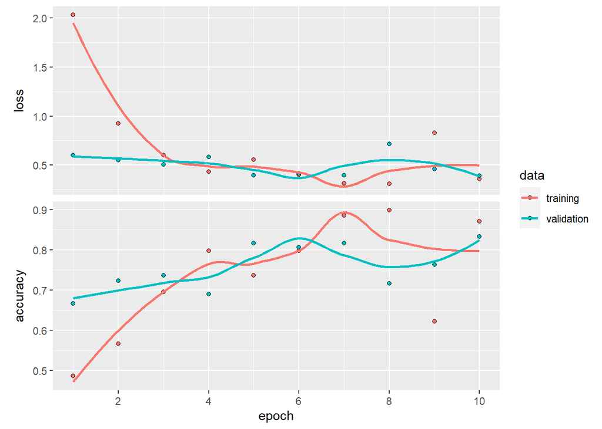

```r
plot(hot_dog_model_final_inceptionV3_RDS)
```

We can clearly see the superiority of Google’s neural network, which begs the question of whether a data scientist is always better off working alone or if the data science community can come to the rescue. Our results seem to point to the latter case.

As a final remark, it is worthwhile to mention that the number of epochs were always kept low due to a low computational power on the data scientist’s laptop. More stable performance would have achieved had there been more computational resources.